# Problema 3: Teorema del límite central

Ricardo_Vargas_M

2025-09-15

## Problema 3:Teorema del limite central

En una planta de fabricación de componentes electrónicos, se modela el tiempo (meses) de funcionamiento continuo de una máquina antes de necesitar mantenimiento mediante una distribución Exponencial. El análisis ha determinado que el tiempo hasta el primer mantenimiento sigue una distribución Exponencial con parámetro λ=0.16

La distribución exponencial definida por:
$$X \sim \text{Exp}(\lambda)$$

### a. Cálculo de la media y varianza de la población:

Para la distribución exponencial su media:
$$\mathbb{E}[X] = \frac{1}{\lambda}$$
la varianza:
$$\text{Var}(X) = \frac{1}{\lambda^{2}}$$
Realizando el calculo reemplazando el valor de $\lambda$ obtenemos:

```
## # A tibble: 1 × 2
##   media_poblacional var_poblacional
##               <dbl>           <dbl>
## 1              6.25            39.1
```

Una maquina puede funcionar alrededor de 6.25 meses antes del mantenimiento.El valor de la varianza es bastante alto por lo tanto habra maquinas que fallen mucho antes o tal vez mucho despues del valor que estamos estimando

### b. Gráfico de la curva de densidad:

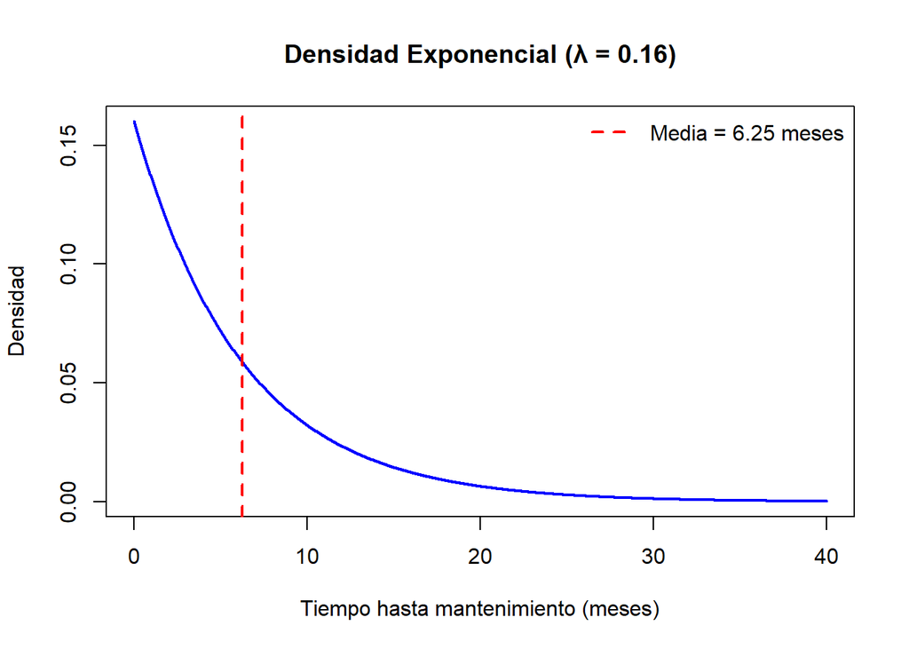

### c. Comparación de parámetros, estimadores y estimaciones: Toma 10 muestras aleatorias de tamaño n=200

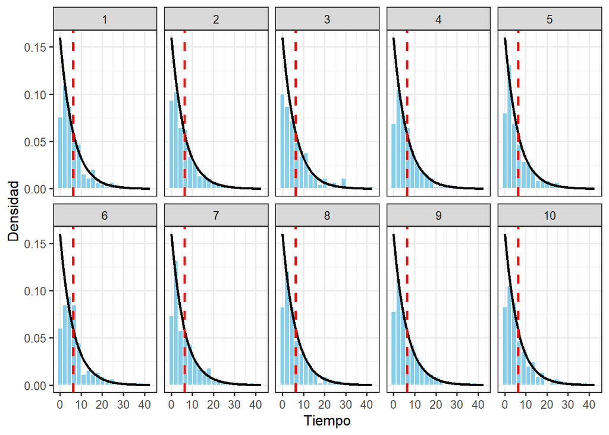

Viendo la comparación de las graficas de histogramas vs la curva vemos que puede y logra representar en una gran mayoria la “realidad” de los datos. Las muestras que presentan errores se deben al error muestral puesto que al ser diferentes las 10 muestras entre si los valores fluctuan. Con un mayor tamaño de la muestra, las diferencias tienden a disminuir

```
##    muestra media_muestral var_muestral   dif_media    dif_var
## 1        1       6.057435     35.17295 -0.19256475 -3.8895485
## 2        2       6.136170     39.73698 -0.11382971  0.6744764
## 3        3       6.666819     52.80783  0.41681871 13.7453333
## 4        4       6.298453     35.03840  0.04845266 -4.0241048
## 5        5       5.876027     36.43993 -0.37397345 -2.6225719
## 6        6       6.796952     43.82824  0.54695208  4.7657362
## 7        7       6.074150     35.66198 -0.17585041 -3.4005217
## 8        8       5.589301     29.92203 -0.66069850 -9.1404716
## 9        9       6.490332     46.08218  0.24033171  7.0196824
## 10      10       6.390493     47.48729  0.14049330  8.4247865
##  media_poblacional    var_poblacional promedio_de_medias    promedio_de_var
##             6.2500            39.0625             6.2376            40.2178
##   sd_de_las_medias
##             0.3664
```

### d. Aplicación del Teorema del Límite Central para n=200:

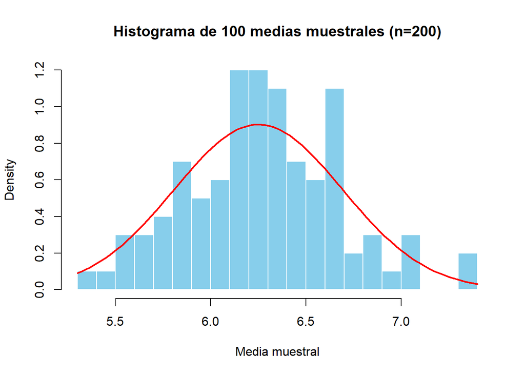

```
## promedio_medias varianza_medias
##       6.2716550       0.1528187
##
##  Shapiro-Wilk normality test
##
## data:  medias
## W = 0.99219, p-value = 0.8347
```

A pesar de que la distribución original es exponencial y asimetrica vemos como el histograma tiene cierta aproximación a una distribucion normal, la curva en Rojo representa la aproximacion del Teorema del limite central (TLC). El promedio de las medias muestrales tiene un valor de 6.27 muy cercano variando unicamente en el 2 decimal y por 2 decimas del valor esperado 6.25, lo cual siginifica que se encuentra relativamente cerca respecto a la teoria. Con respecto a la varianza el valor se redujo con un valor de 0.153 con respecto al valor esperado 0.195, en este caso puede estar faltando cantidad de muestras.

El test de normalidad (shapiro-wilk con α=0.05) presenta lo siguiente:

H0= las 100 medias muestrales provienen de una distribución normal. Debido a que el valor supero 0.05 bi se rechaza la hipotesis de normalidad, significando que las 100 medias no muestran evidencia de desviarse de la distribucion normal.

Por lo tanto el teorema del limite central se puede mostrar. A mayor numero de n, la distribución tiende a normal inpendiente de su modelo.

### e. Aplicación del Teorema del Límite Central variando n:

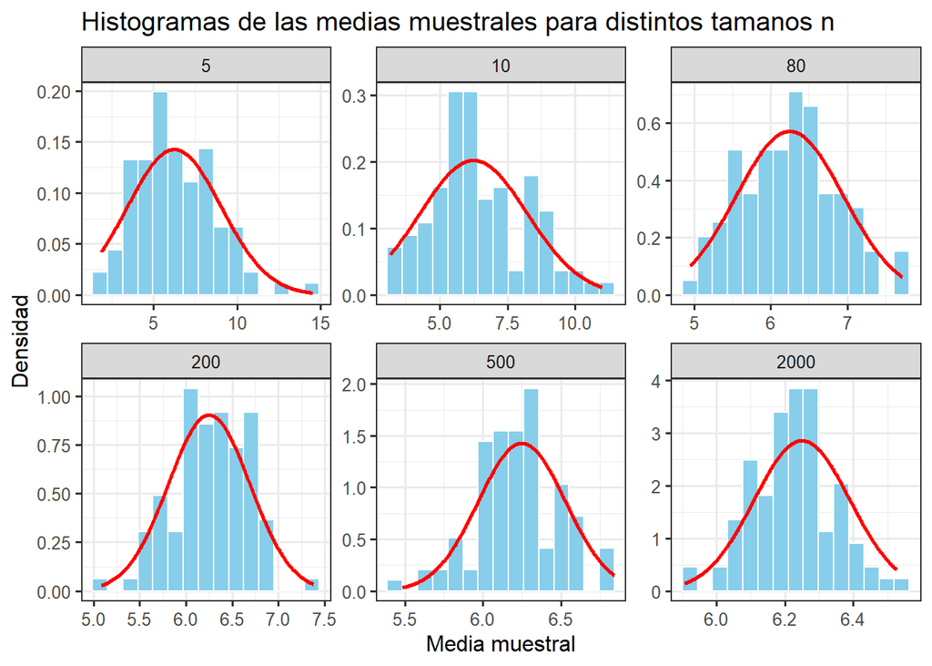

Como podemos ver para los tamaños de muestra mas pequeños, los histogramas de las medias tienen cierta asimetria, sin duda alguna esto se debe a que la distribucion original es exponencial, a partir de n=80 se comienza a ver la evolución hacia la campana simetria asemejandose a la distribución normal en donde la muestra mayor se puede representar en gran parte por esta distribución

Resumen por tamaño muestral (100 réplicas por n)

| n | Promedio empirico | Varianza empirica | Promedio teorico | Varianza teorica |
| --- | --- | --- | --- | --- |
| 5 | 6.29 | 5.64 | 6.25 | 7.81 |
| 10 | 6.43 | 3.02 | 6.25 | 3.91 |
| 80 | 6.25 | 0.40 | 6.25 | 0.49 |
| 200 | 6.27 | 0.16 | 6.25 | 0.20 |
| 500 | 6.23 | 0.07 | 6.25 | 0.08 |
| 2000 | 6.22 | 0.01 | 6.25 | 0.02 |

En los tamaños de muestra el promedio empirico estuvo cercano a la teoria igual que la varianza, pero conforme vemos que el tamaño de la muestra aumenta tambien de cierta forma su precisión de la teoria vs la simulación

```
## # A tibble: 6 × 2
##       n shapiro_p
##   <dbl>     <dbl>
## 1     5    0.0510
## 2    10    0.0584
## 3    80    0.582
## 4   200    0.431
## 5   500    0.509
## 6  2000    0.942
```